# Homework for 14 I 2016

Michał Frej

Let’s take a look at our data. First six rows are

```r
library("nlme")
library("ade4")
spdata <- read.table("http://www.ats.ucla.edu/stat/r/faq/thick.csv", header = T, sep = ",")
head(spdata)
```

```
##   X east north thick     soil dummy
## 1 1  0.7  59.6  34.1 3.635764     1
## 2 2  2.1  82.7  42.2 3.502083     1
## 3 3  4.7  75.1  39.5 3.946545     1
## 4 4  4.8  52.8  34.3 2.941715     1
## 5 5  5.9  67.1  37.0 3.866264     1
## 6 6  6.0  35.7  35.9 3.018548     1
```

Graphically it looks like there is no significant dependancy between thick and soil.

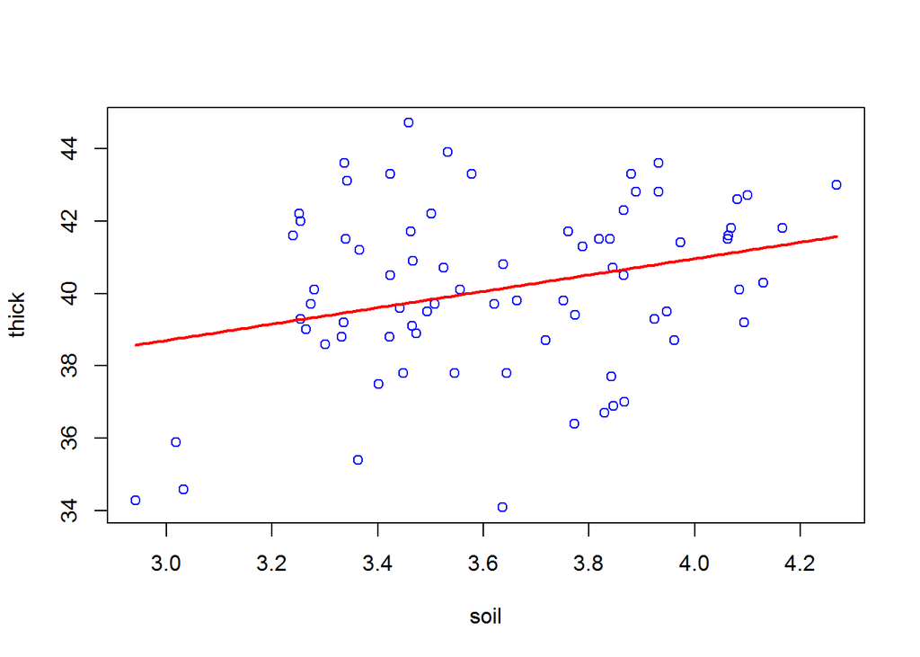

```r
plot(thick~soil, data=spdata,col="blue")

modelSimple <- lm(thick~soil, data=spdata)
a=as.numeric(modelSimple$coefficients[2])
b=as.numeric(modelSimple$coefficients[1])
curve(a*x+b,min(spdata$soil),max(spdata$soil),add=TRUE,col="red",lwd=2)
```

However simple linear model tells us, that slope is nonzero.

```r
summary(modelSimple)
```

```
##
## Call:
## lm(formula = thick ~ soil, data = spdata)
##
## Residuals:
##     Min      1Q  Median      3Q     Max
## -6.0414 -1.1975  0.0876  1.4836  4.9584
##
## Coefficients:
##             Estimate Std. Error t value Pr(>|t|)
## (Intercept)  31.9420     3.1570  10.118 1.54e-15 ***
## soil          2.2552     0.8656   2.605   0.0111 *
## ---
## Signif. codes:  0 '***' 0.001 '**' 0.01 '*' 0.05 '.' 0.1 ' ' 1
##
## Residual standard error: 2.278 on 73 degrees of freedom
## Multiple R-squared:  0.08508,    Adjusted R-squared:  0.07254
## F-statistic: 6.788 on 1 and 73 DF,  p-value: 0.01111
```

Assumptions of linear model are fulfilled, as residuals are normal.

```r
shapiro.test(residuals(modelSimple))
```

```
##
##  Shapiro-Wilk normality test
##
## data:  residuals(modelSimple)
## W = 0.98776, p-value = 0.6898
```

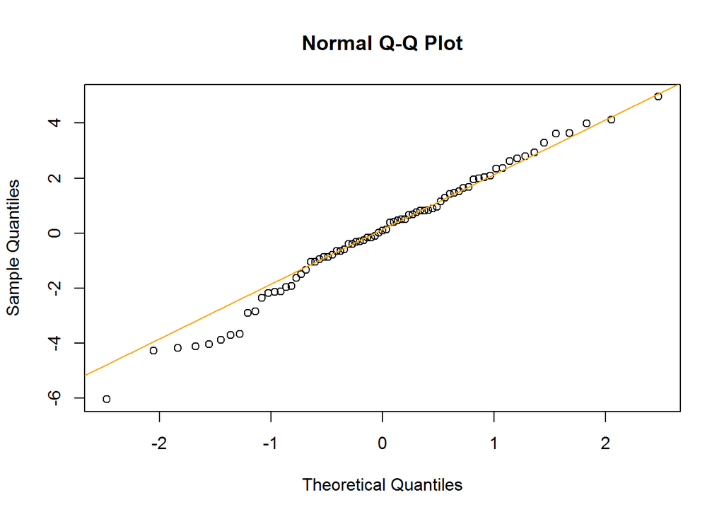

```r
qqnorm(residuals(modelSimple))
qqline(residuals(modelSimple),col="orange")
```

Our intuition tells us, that the dependant variable should depend on geographical distance. By looking at variogram and Mantel test we’ll check if our guess is good.

```r
mantel.rtest(dist(spdata[,2:3]),dist(spdata$thick),nrepet=9999)
```

```
## Monte-Carlo test
## Observation: 0.1925625
## Call: mantel.rtest(m1 = dist(spdata[, 2:3]), m2 = dist(spdata$thick),
##     nrepet = 9999)
## Based on 9999 replicates
## Simulated p-value: 1e-04
```

Simulated p-value is very low, so probably there is a relation between distance and thick.

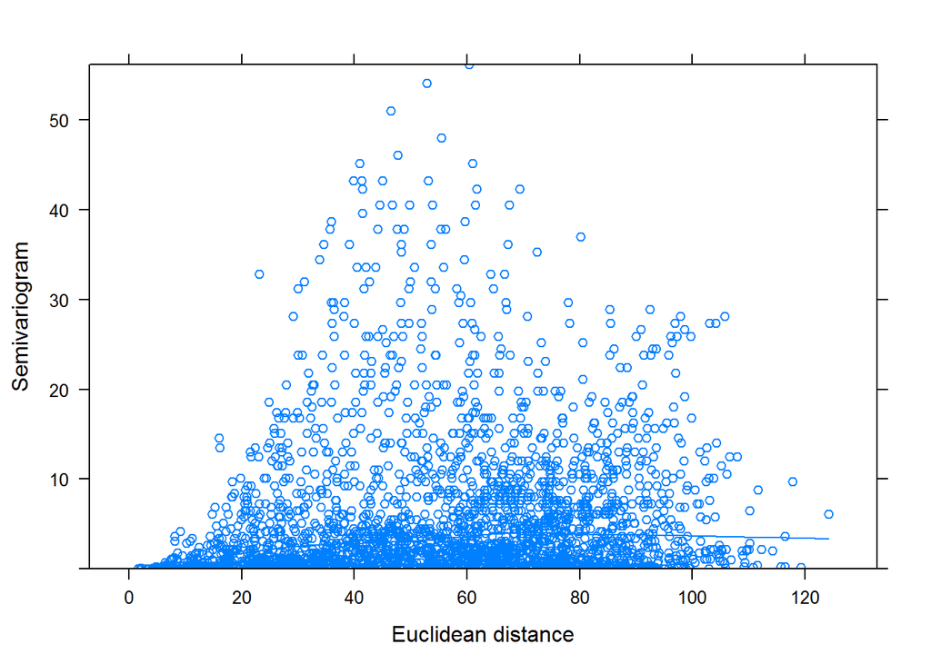

```r
plot(Variogram(spdata$thick,dist(spdata[,2:3])),xlab="Euclidean distance",span=0.4)
```

After a close look at this plot we see that for distances <=60 there is a linear trend. Therefore it’s reasonable to add geographical distance to our model. We’ll do this by setting different correlation matrix.

```r
modelGaus <- lme(fixed = thick ~ soil, data = spdata, random = ~ 1 | dummy,correlation = corGaus(1, form = ~ east + north), method = "ML")

modelSpher <- lme(fixed = thick ~ soil, data = spdata, random = ~ 1 | dummy,correlation = corSpher(1, form = ~ east + north), method = "ML")

modelExp <- lme(fixed = thick ~ soil, data = spdata, random = ~ 1 | dummy,correlation = corExp(1, form = ~ east + north), method = "ML")

modelLin <- lme(fixed = thick ~ soil, data = spdata, random = ~ 1 | dummy,correlation = corLin(1, form = ~ east + north), method = "ML")

modelRatio <- lme(fixed = thick ~ soil, data = spdata, random = ~ 1 | dummy,correlation = corRatio(1, form = ~ east + north), method = "ML")

stats <- function(model){
      c(AIC(model),BIC(model),logLik(model))
}

comp <- data.frame(Simple=stats(modelSimple),Gaus=stats(modelGaus),
                  Spher=stats(modelSpher),Exp=stats(modelExp),
                  Lin=stats(modelLin),Ratio=stats(modelRatio))
rownames(comp) <- c("AIC","BIC","LogLikelihood")
comp <- t(comp)
comp
```

```
##              AIC       BIC LogLikelihood
## Simple 340.31818 347.27065    -167.15909
## Gaus    91.50733 103.09477     -40.75366
## Spher  344.31832 355.90576    -167.15916
## Exp    169.10406 180.69150     -79.55203
## Lin    167.46966 179.05710     -78.73483
## Ratio   56.02011  67.60755     -23.01006
```

The best AIC,BIC and log likelihood has modelRatio. Let’s look at details of this model to see, that it has much better estimates of intercept and slope then simple linear model(it has smaller standard deviation of this coefficients).

```r
summary(modelRatio)
```

```
## Linear mixed-effects model fit by maximum likelihood
##  Data: spdata
##        AIC      BIC    logLik
##   56.02011 67.60755 -23.01006
##
## Random effects:
##  Formula: ~1 | dummy
##          (Intercept) Residual
## StdDev: 0.0002023259 2.553953
##
## Correlation Structure: Rational quadratic spatial correlation
##  Formula: ~east + north | dummy
##  Parameter estimate(s):
##    range
## 33.15116
## Fixed effects: thick ~ soil
##                Value Std.Error DF   t-value p-value
## (Intercept) 40.93084 1.3340861 73 30.680810  0.0000
## soil        -0.00414 0.0170917 73 -0.242092  0.8094
##  Correlation:
##      (Intr)
## soil -0.028
##
## Standardized Within-Group Residuals:
##        Min         Q1        Med         Q3        Max
## -2.6687253 -0.8091678 -0.3186992  0.3270839  1.4814169
##
## Number of Observations: 75
## Number of Groups: 1
```

This model(p-value equal to 0.8094) tells us, that the ralation between thick and soil is not significant. Now we’ll check whether modelRation is a proper mixed model.

```r
shapiro.test(residuals(modelRatio))
```

```
##
##  Shapiro-Wilk normality test
##
## data:  residuals(modelRatio)
## W = 0.97157, p-value = 0.08938
```

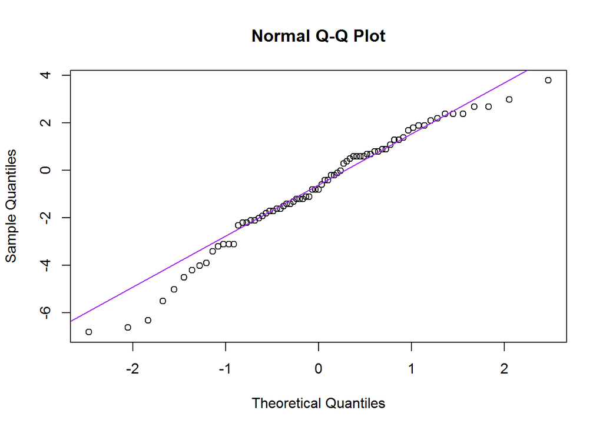

```r
qqnorm(residuals(modelRatio))
qqline(residuals(modelRatio),col="purple")
```

The qqplot looks badly, but the sample size is quite small. Shapiro-Wilk test does not reject the null hypothesis(residuals are normal) on the level 5%.

The modelRadio model is better for our data than simple linear model. In model with spatial structure the soil variable is not significant, therefore I think, that there is no important relation between soil and thick.